# serving

Rebstock

7/13/2021

Local Bus 2018-2023

https://www.loudoun.gov/DocumentCenter/View/122385/TDP-2018-2028-?bidId=

https://www.loudoun.gov/3444/Transit-Development-Plan

- Serves 3 shopping centers
- Start point is a stop in the Shenandoah Square shopping center north of the County offices (Shenandoah Building) and adjacent to Mail Stop
- The route has never charged a fare. The Town of Leesburg contributes a portion of the cost to fund the service

```r
# number of riders monthly for weekdays, saturday, sunday
mar15 <- c(1148, 228, 210)
# average of riders for weekday, sat, sun
averg <- c(52, 57, 42)
```

OAR 2020

https://oarnova.org/accountability/financial-documents

2020 report

https://www.oarnova.org/images/FY_2020_AR.pdf

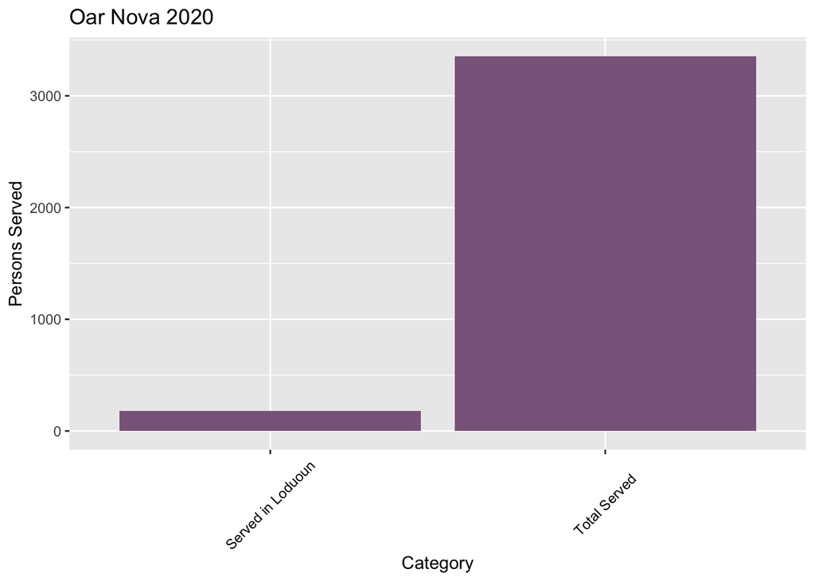

```r
library(ggplot2)
# 2020
l <- 180
c <- 3355
m <- 75
f <- 23
undisclosed <- 2

tay <- 30
no_high <- 17
college <- 11

all <- data.frame(rbind(l, c, m, f, undisclosed, tay, no_high, college))
all$Category <- c("Served in Loduoun",
                  "Total Served",
                  "Male",
                  "Female",
                  "Undisclosed Gender",
                  "TAYs",
                  "Did not finish high school",
                  "Have a college education")
colnames(all) <-c("Number", "Category")
all$Category <- factor(all$Category, levels=unique(all$Category))


ggplot() + geom_col(mapping = aes(Category, Number), data = all[1:2,],fill =  "plum4") +
  labs(title = "Oar Nova 2020",
       y = "Persons Served")+
  theme(axis.text.x = element_text(angle = 45, vjust = .5, color = "black"))
```

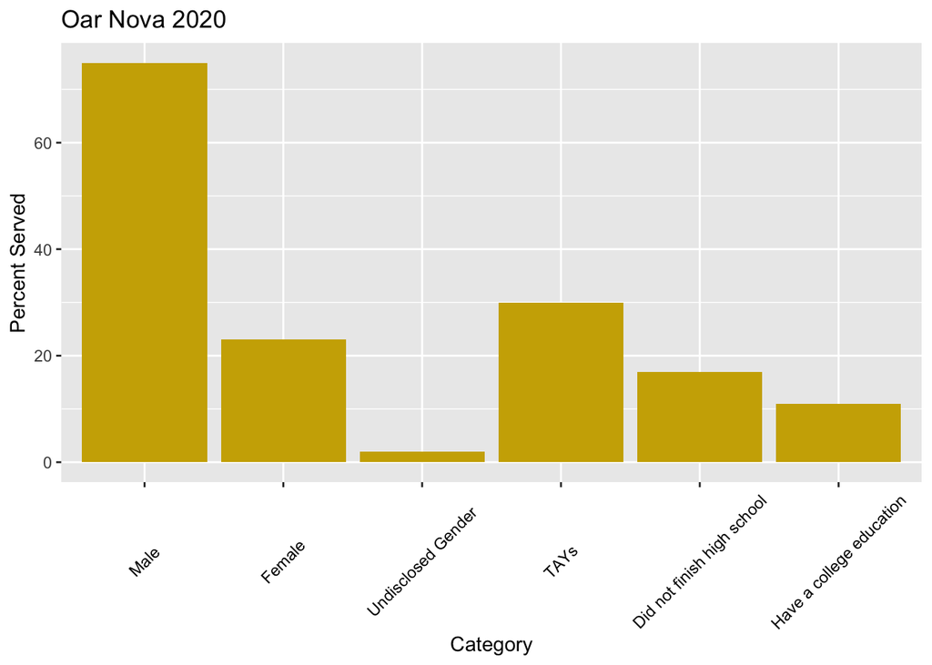

```r
ggplot() + geom_col(mapping = aes(Category, Number), data = all[3:8,],fill =  "gold3") +
  labs(title = "Oar Nova 2020",
       y = "Percent Served") +
  theme(axis.text.x = element_text(angle = 45, vjust = .5, color = "black"))
```

```r
#2019
l <- 221
c <- 4757
m <- .72
f <- .27

tay <- .36
no_high <- .15
college <- .11

#2018
l <- 142
c <- 3917
m <- .76
f <- .24

tay <- .36
no_high <- .15

#2017
l <- 159
c <- 3413
m <- .75
f <- .24

tay <- .31
no_high <- .19
```

Oxford House for all Virginia Houses November 2019 -2020

https://oxfordhouse.org/userfiles/file/evaluations.php https://oxfordhouse.org/userfiles/file/doc/eval_va2020.pdf

They take 17-74 ages, NO time limit as long as they stay sober

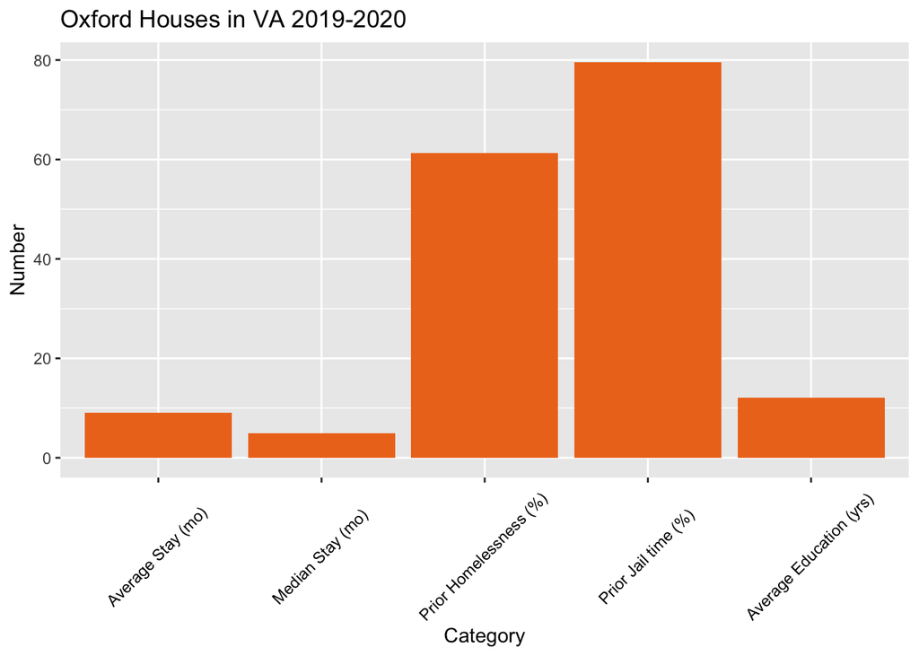

```r
average_stay <- 9 #months
median_stay <- 5
prior_home <- 61.3 #percent
prior_jail <- 79.6
edu <- 12.1 #years

ox <- data.frame(rbind(average_stay, median_stay, prior_home, prior_jail, edu))
ox$Category <- c("Average Stay (mo) ",
                  "Median Stay (mo) ",
                  "Prior Homelessness (%) ",
                  "Prior Jail time (%) ",
                  "Average Education (yrs) ")
colnames(ox) <-c("Number", "Category")
ox$Category <- factor(ox$Category, levels=unique(ox$Category))


ggplot() + geom_col(mapping = aes(Category, Number), data = ox,fill =  "chocolate2") +
  labs(title = "Oxford Houses in VA 2019-2020",
       y = "Number") +
  theme(axis.text.x = element_text(angle = 45, vjust = .5, color = "black"))
```

Medicaid (all of VA) july 2021

Monthly enrollments

https://www.dmas.virginia.gov/media/3619/dmas-enrollment-report-july-2021.pdf https://www.dmas.virginia.gov/media/3503/medicaid-expansion-infographic.pdf https://www.dmas.virginia.gov/data/

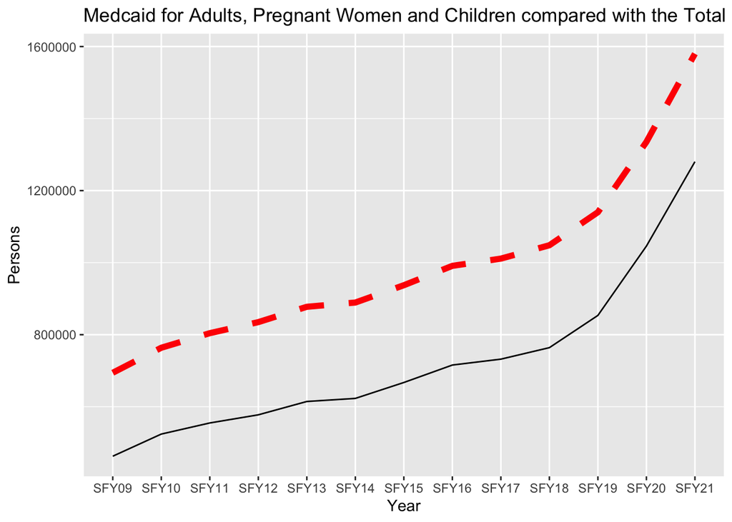

```r
library(readxl)
library(ggplot2)
enroll <- read_excel("~/Desktop/Virginia-Tech/DSPG-2021/Loudoun-County/2021_DSPG_Loudoun/ShinyApp/data/medicaid-enrollment.xlsx")


total <- enroll[1:13,]
total$`Adults, Pregnant Women and Children` <- as.numeric(total$`Adults, Pregnant Women and Children`)
med <- enroll[16:20,1:3]
colnames(med) <- c("Year", "Children", "Childless Adults")
med$`Childless Adults` <- as.numeric(med$`Childless Adults`)
med$Children <- as.numeric(med$Children)



ggplot() +
  geom_line(mapping = aes(Year, `Adults, Pregnant Women and Children`, group = 1), data = total) +
  geom_line(mapping = aes(Year, Total, group = 1), data = total, linetype = "dashed", color="red", size = 2) +
  labs(y = "Persons",
       title = "Medcaid for Adults, Pregnant Women and Children compared with the Total")
```

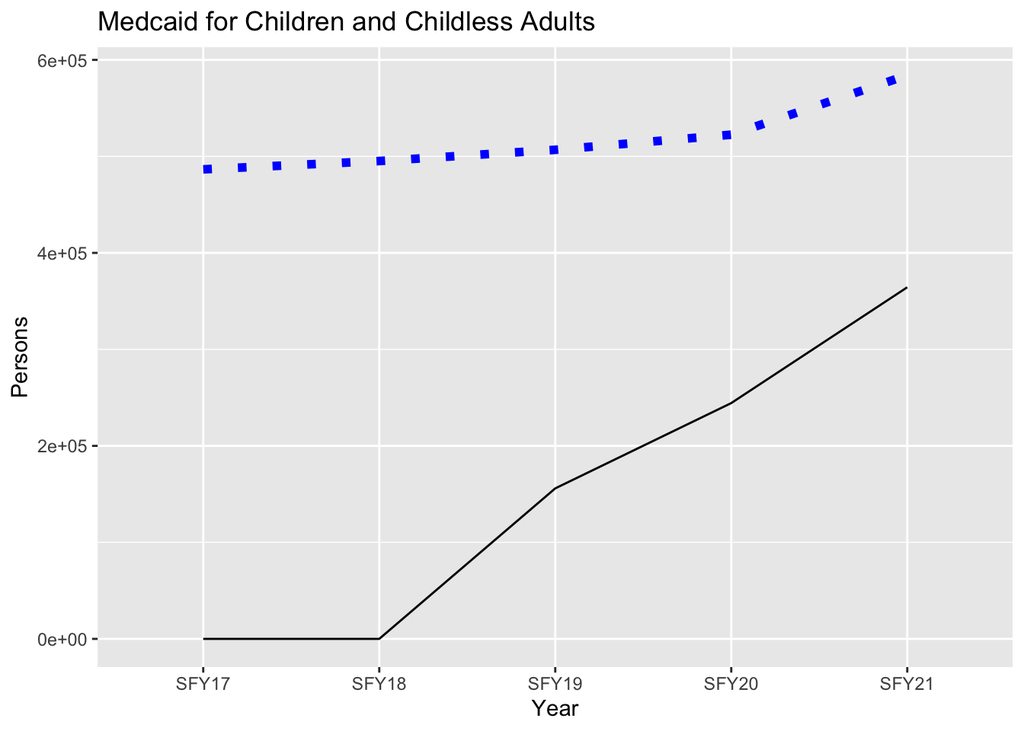

```r
ggplot() +
  geom_line(mapping = aes(Year, `Childless Adults`, group = 1), data = med) +
  geom_line(mapping = aes(Year, Children, group = 1), data = med, linetype = "dotted", color="blue", size = 2) +
  labs(y = "Persons",
       title = "Medcaid for Children and Childless Adults")
```

WIOA Monthly reports 2020

https://vcwnorthern.com/program-reports/

**potentially getting the raw data**

Affordable Dwelling Unit Program 2020

**potentially getting the raw data**

Monthly reports on how many ADU are sold and rented out and a waitlist number https://www.loudoun.gov/431/Affordable-Dwelling-Unit-Advisory-Board

Continuum of Care Homeless Shelters in Northern VA 202-2021

file:///Users/julierebstock/Downloads/2021_PIT_Combined1.pdf https://www.mwcog.org/documents/2021/05/05/homelessness-in-metropolitan-washington-results-and-analysis-from-the-annual-point-in-time-pit-count-of-persons-experiencing-homelessness-featured-publications-homelessness/

Jennifer Hope Continuum of Care Coordinator Loudoun County Department of Family Services (703) 771-5881 Jennifer.Hope@loudoun.gov

```r
# homeless Single transition aged youth in 2021 in Loudoun
x_2017 <- 10
x_2018 <- 7
x_2019 <-20
x_2020 <- 22
x_2021 <-12

# total single adults (TAYs) in the regions included
total <- 453
fc <- 92
black <- .80
white <- .12
multi <- .5


#Number of Literally Homeless TAYs (single adults and family hosueholds) in Loudoun
percent_21 <- .21
x_2021 <- 16
x_2020 <- 22
x_2019 <- 17

# Housing Inventory as of Jan 2021 in Loudoun
year_round_emer <- 58
year_round_transition <- 28
hypothermia <- 26
perm <- 21
domestic <- 12
```

Good Shepherd Alliance

**if can get more data**

https://goodshepherdalliance.org/how-we-serve/

3000+ are helped each year 10000+ beds 77% go on to stable housing following

Adult Literacy Program Loudoun

**not super specific on what ages**

https://loudounliteracy.org/wp-content/uploads/2020/11/Annual-Report-FY20.pdf

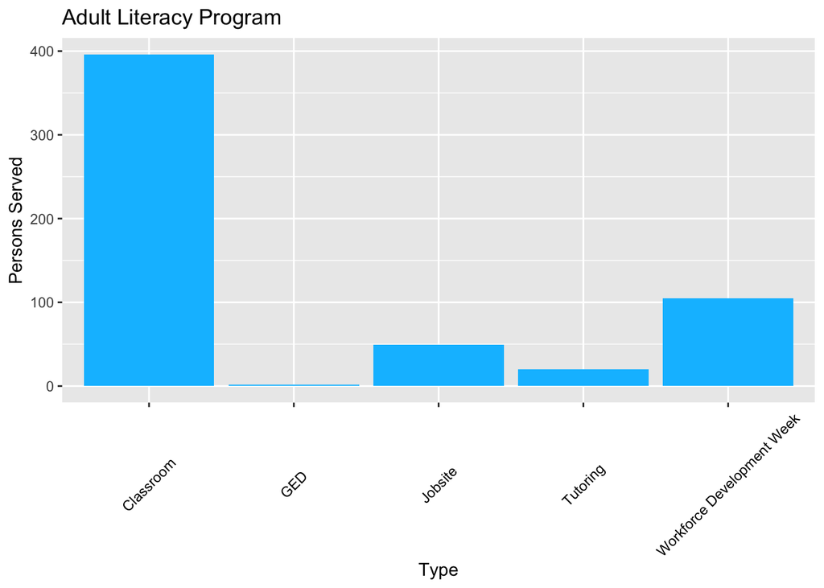

```r
classroom <- 396
tutoring <- 20
jobsite <- 49
ged <- 2
workforce <- 105

programs <- data.frame((rbind(classroom, tutoring, jobsite, ged, workforce)))
programs$Type <- c("Classroom", "Tutoring", "Jobsite", "GED", "Workforce Development Week")
colnames(programs) <- c("Number", "Type")

ggplot() + geom_col(mapping = aes(Type, Number), data = programs,fill =  "deepskyblue1") +
  labs(title = "Adult Literacy Program",
       y = "Persons Served")+
  theme(axis.text.x = element_text(angle = 45, vjust = .5, color = "black"))
```

```r
served <- 543
hispanic <- 58
asian <- 24
white <- 10
other <- 6
```

Culmore Clinic

**not specific on ages** https://www.culmoreclinic.org/patient-enrollment

65% are employed $10,945 annual income 90% require English interpretation services 69% are 30 to 64 years old; 10% are 18 to 29; 10% are 65 and over. 36% are male and 64% are female 65% of these patients have been with us for 3-4 years. We are their primary care. 2,188 providers visits 885 patient calls